# Transcriptome analysis of mammary adipose tissue

Dev Raj Bhattarai

5/7/2022

Analyzing the RNASeq data using DESeq2 standard workflow vignette

Citation - Love, M.I., Huber, W., Anders, S. (2014) Moderated estimation of fold change and dispersion for RNA-seq data with DESeq2. Genome Biology, 15:550. 10.1186/s13059-014-0550-8

I have downloaded a gene expression file named “Tumor-associated and control mammary adipose tissue in lean and high fat diet-induced obese mice” with an GEO accession number - GSE201316. The file is located at D:Paperwith .txt format

Reading the file

```r
main_data <- read.table("GSE201316_allCounts.txt", header = TRUE, sep = "\t", row.names = 1)
main_data <- data.frame(main_data)
```

Creating a metadata

```r
samples <- c("X0.C.2_L_S5","X0.C.2_R_S10", "X0.H.2_L_S16", "X0.H.2_R_S22", "X1.H.2_L_S11", "X1.H.2_R_S17", "X2.C.2_L_S1", "X2.C.2_R_S6", "X2.H.2_L_S12", "X2.H.2_R_S18", "X3.C.2_L_S2", "X3.C.2_R_S7", "X3.H.2_L_S13", "X3.H.2_R_S19", "X4.H.2_L_S14", "X4.H.2_R_S20", "X6.C.2_L_S3", "X6.C.2_R_S8", "X8.H.2_L_S15", "X8.H.2_R_S21", "X9.C.2_L_S4", "X9.C.2_R_S9" )
treatment <- c("CD", "CD", "HFD", "HFD", "HFD", "HFD", "CD", "CD", "HFD", "HFD", "CD", "CD", "HFD", "HFD", "HFD", "HFD", "CD", "CD", "HFD", "HFD","CD", "CD")
tumor_status <- c("T", "C", "T", "C", "T", "C", "T", "C", "T", "C", "T", "C", "T", "C", "T", "C", "T", "C", "T", "C", "T", "C")
group <- c("CD_T", "CD_C", "HFD_T", "HFD_C", "HFD_T", "HFD_C", "CD_T", "CD_C", "HFD_T", "HFD_C", "CD_T", "CD_C", "HFD_T", "HFD_C", "HFD_T", "HFD_C", "CD_T", "CD_C", "HFD_T", "HFD_C", "CD_T", "CD_C")
meta_data <- data.frame(samples, treatment, tumor_status, group, stringsAsFactors = FALSE, row.names = 1)
```

Checking if all of the row names of the meta_data are in the same order as the column names of the main_counts data

```r
all(rownames(meta_data) == colnames(main_data))
```

```
## [1] TRUE
```

creating DESeq object

```r
dds <- DESeqDataSetFromMatrix(countData = main_data, colData = meta_data, design = ~tumor_status)
dds
```

```
## class: DESeqDataSet
## dim: 23425 22
## metadata(1): version
## assays(1): counts
## rownames(23425): 0610005C13Rik 0610007N19Rik ... __not_aligned
##   __alignment_not_unique
## rowData names(0):
## colnames(22): X0.C.2_L_S5 X0.C.2_R_S10 ... X9.C.2_L_S4 X9.C.2_R_S9
## colData names(3): treatment tumor_status group
```

pre-filtering

```r
keep <- rowSums(counts(dds)) >= 10
dds <- dds[keep,]
dds
```

```
## class: DESeqDataSet
## dim: 17397 22
## metadata(1): version
## assays(1): counts
## rownames(17397): 0610005C13Rik 0610007N19Rik ... __ambiguous
##   __alignment_not_unique
## rowData names(0):
## colnames(22): X0.C.2_L_S5 X0.C.2_R_S10 ... X9.C.2_L_S4 X9.C.2_R_S9
## colData names(3): treatment tumor_status group
```

Normalization

```r
dds <- estimateSizeFactors(dds)
sizeFactors(dds)
```

```
##  X0.C.2_L_S5 X0.C.2_R_S10 X0.H.2_L_S16 X0.H.2_R_S22 X1.H.2_L_S11 X1.H.2_R_S17
##    0.9600867    1.2301293    0.9063180    0.8878331    1.1058687    1.0018782
##  X2.C.2_L_S1  X2.C.2_R_S6 X2.H.2_L_S12 X2.H.2_R_S18  X3.C.2_L_S2  X3.C.2_R_S7
##    0.9261003    0.8169404    1.0456395    1.1547322    1.0655689    0.9367397
## X3.H.2_L_S13 X3.H.2_R_S19 X4.H.2_L_S14 X4.H.2_R_S20  X6.C.2_L_S3  X6.C.2_R_S8
##    1.1114984    1.1480839    1.0767429    0.9433002    1.1197609    0.8113911
## X8.H.2_L_S15 X8.H.2_R_S21  X9.C.2_L_S4  X9.C.2_R_S9
##    1.0184498    1.0180931    0.9365831    0.8490520
```

Extracting normalized counts

```r
normalizedmain_data <- counts(dds, normalized = TRUE)
```

performing log transformation

```r
vsd <- vst(dds, blind = TRUE)
```

Extracting the vst matrix

```r
vsd_matrix <- assay(vsd)
```

computing pairwise correlation value

```r
vsd_cor <- cor(vsd_matrix)
```

Plotting the heatmap

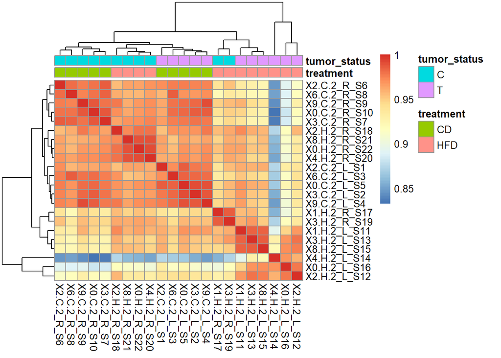

```r
library(pheatmap)
pheatmap(vsd_cor, annotation = dplyr::select(meta_data, c("treatment", "tumor_status")))
```

visualizing PCA plot

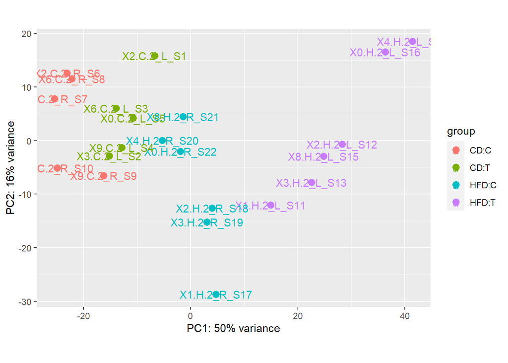

```r
p <- plotPCA(vsd, intgroup = c("treatment", "tumor_status"))
p + geom_text(aes(label = rownames(meta_data)))
```

creating DESeq object

```r
dds <- DESeqDataSetFromMatrix(countData = main_data, colData = meta_data, design = ~treatment + tumor_status + treatment:tumor_status)
dds$treatment
```

```
##  [1] CD  CD  HFD HFD HFD HFD CD  CD  HFD HFD CD  CD  HFD HFD HFD HFD CD  CD  HFD
## [20] HFD CD  CD
## Levels: CD HFD
```

```r
dds$tumor_status
```

```
##  [1] T C T C T C T C T C T C T C T C T C T C T C
## Levels: C T
```

Running analysis

```r
dds <- DESeq(dds)
resultsNames(dds)
```

```
## [1] "Intercept"                  "treatment_HFD_vs_CD"
## [3] "tumor_status_T_vs_C"        "treatmentHFD.tumor_statusT"
```

Exploring Log2fold change

```r
l2f <- results(dds, name ="treatmentHFD.tumor_statusT" , alpha = 0.05)
```

Differentially expressed genes

```r
summary(l2f)
```

```
##
## out of 19842 with nonzero total read count
## adjusted p-value < 0.05
## LFC > 0 (up)       : 1261, 6.4%
## LFC < 0 (down)     : 1102, 5.6%
## outliers [1]       : 49, 0.25%
## low counts [2]     : 4941, 25%
## (mean count < 5)
## [1] see 'cooksCutoff' argument of ?results
## [2] see 'independentFiltering' argument of ?results
```

MA plot

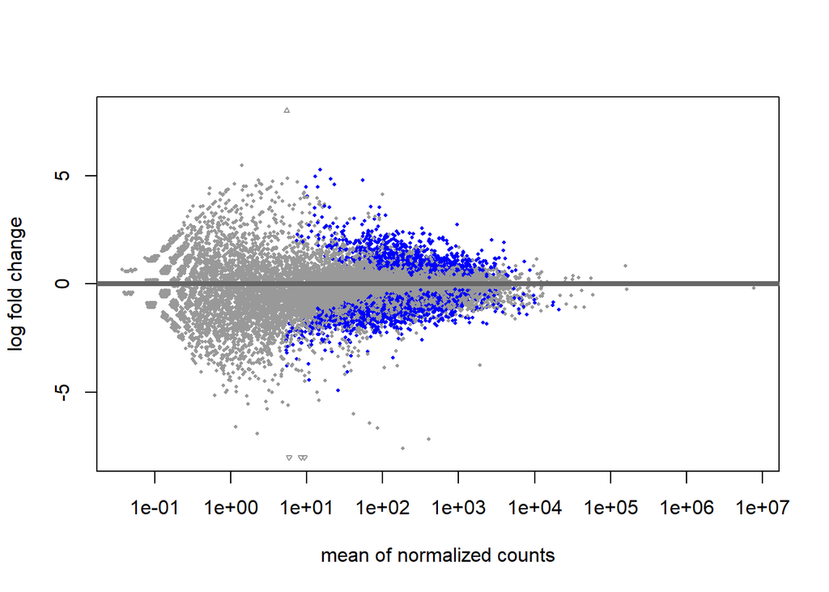

```r
plotMA(l2f, ylim = c(-8,8))
```

creating column indicating if the gene is DE

```r
l2f <- data.frame(l2f) %>%
  rownames_to_column(var = "ensgene")
l2f <- data.frame(l2f)
l2f$diffexpressed <- "NO CHANGE"
l2f$diffexpressed[l2f$log2FoldChange > 0.32 & l2f$padj < 0.05] <- "UP"
l2f$diffexpressed[l2f$log2FoldChange < 0.32 & l2f$padj < 0.05] <- "DOWN"
l2f <- data.frame(l2f)
```

```r
l2f_sig <- data.frame(l2f)
  l2f_sig <-  subset(l2f_sig , padj < 0.05 & abs(log2FoldChange) > 0.32)
  l2f_sig <- l2f_sig %>%
  arrange(padj)
```

sub-setting significant DE genes only

```r
deg_all_main <- data.frame(deg_all)
  deg_all_main <-  subset(deg_all_main , padj < 0.05 & abs(log2FoldChange) > 0.32)
  deg_all_main <- deg_all_main %>%
  arrange(padj)
  deg_all_main <- data.frame(deg_all_main)
  deg_all_main <- deg_all_main[-5,]
  deg_all_main <- data.frame(deg_all_main)
```

sub-setting normalized counts to only significant DE genes

```r
sig_norm_counts <- normalizedmain_data[l2f_sig$ensgene,]
```

Visualizing result- Heatmap

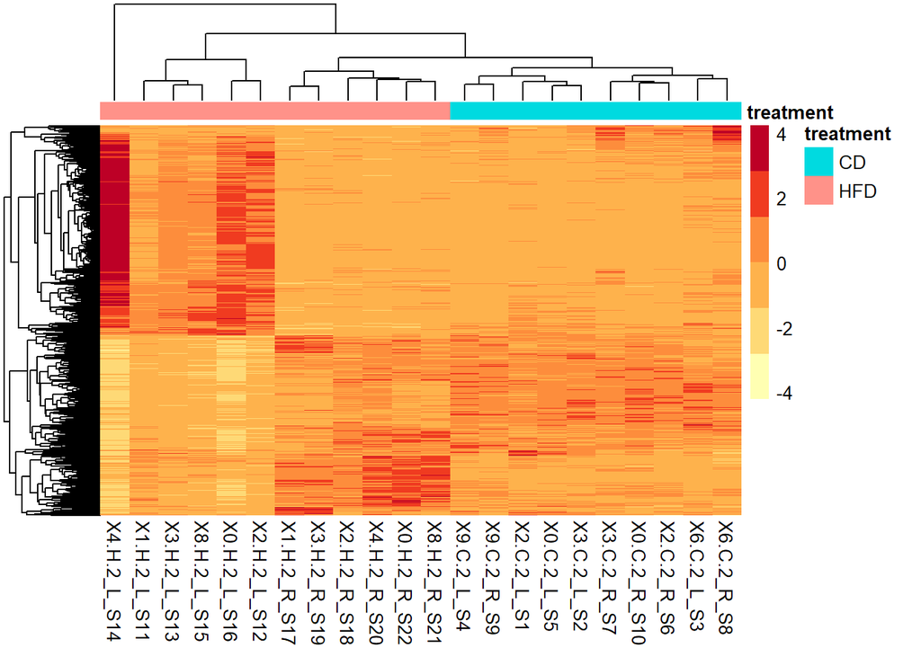

volcano plot

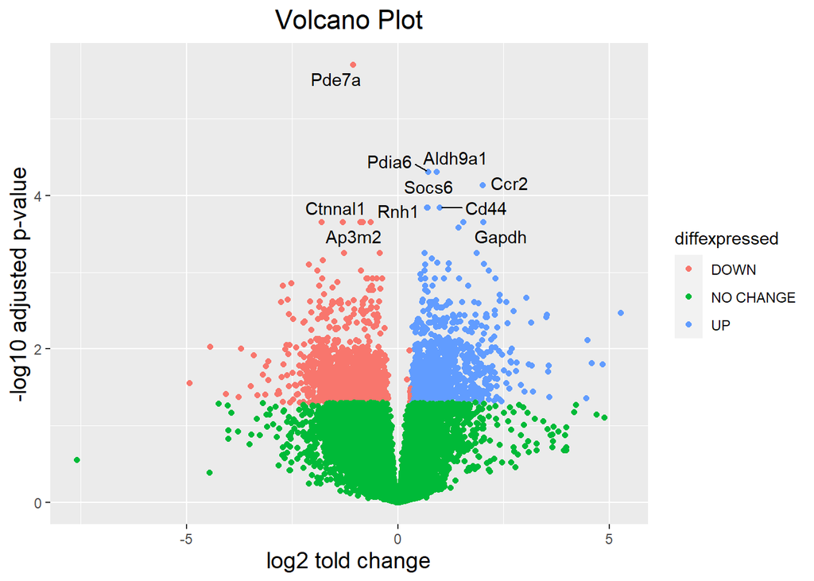

```r
library(ggrepel)
library(ggplot2)
library(tidyverse)
library(dplyr)
deg_all <- deg_all %>%
  arrange(padj) %>%
  mutate(genelabels = "")
deg_all <- data.frame(deg_all)
  deg_all <- deg_all[-5,]
  deg_all <- data.frame(deg_all)
deg_all$genelabels[1:10] <- deg_all$symbol[1:10]

ggplot(deg_all) +
  geom_point(aes(x = log2FoldChange, y = -log10(padj), color = diffexpressed)) +
  geom_text_repel(aes(x = log2FoldChange, y = -log10(padj), label = genelabels)) +
  ggtitle("Volcano Plot") +
  xlab("log2 told change") +
  ylab("-log10 adjusted p-value") +
  theme(plot.title = element_text(size = rel(1.5), hjust = 0.5), axis.title = element_text(size = rel(1.25)))
```

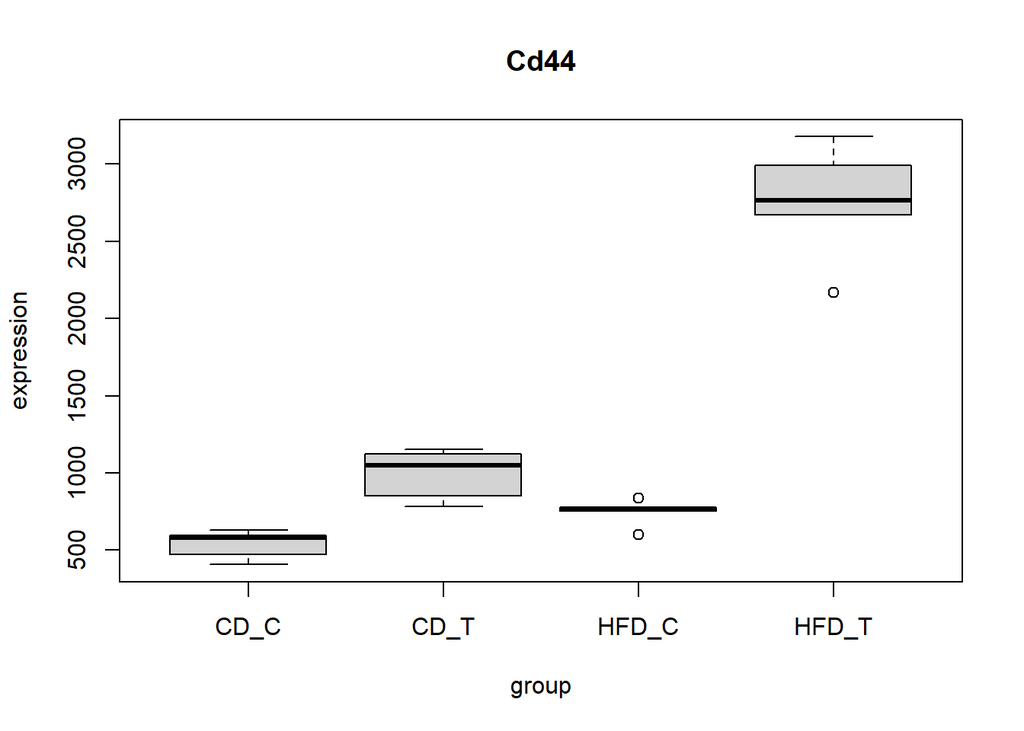

```r
expression <- sig_norm_counts[7,]
group <- meta_data[,"group"]
boxplot(expression ~group, main = l2f_sig[7,"ensgene"])
```

```r
deg_20 <- deg_all_main[1:20,] %>%
  dplyr::select(symbol,description,diffexpressed)
deg_20 <- data.frame(deg_20)
view(deg_20)
```

Preparing input data for enrichment analysis

```r
library(org.Mm.eg.db)
library(AnnotationDbi)
library(annotables)
sig_genes <- data.frame(deg_all)
sig_genes$ensgene <- mapIds(org.Mm.eg.db, keys = sig_genes$ensgene, column = "ENTREZID", keytype = "ENSEMBL", multiVals = "first")
rownames(sig_genes) <- make.names(sig_genes$ensgene, unique = TRUE)
sig_genes <-na.omit(sig_genes)
sig_genes <- data.frame(sig_genes, row.names = NULL)
sig_genes <- data.frame(sig_genes)
```

KEGG pathway enrichment analysis

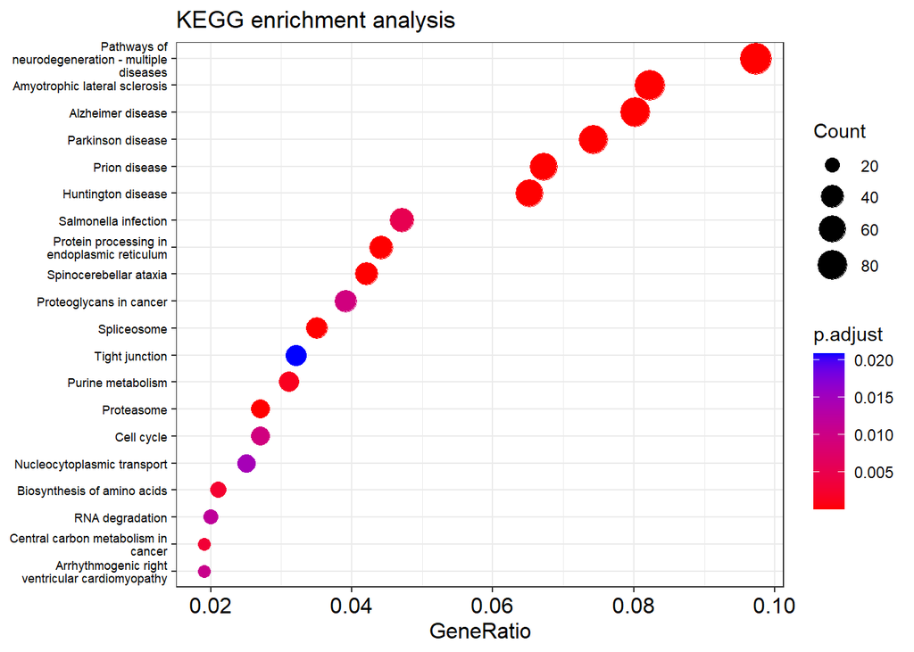

```r
library(clusterProfiler)
library(enrichplot)
library(org.Mm.eg.db)
library(AnnotationDbi)
library(DOSE)
library(dplyr)
library(tidyverse)
all_genes <- sig_genes$ensgene
enriched_pathways <- sig_genes$ensgene[sig_genes$padj < 0.05 & !is.na(sig_genes$log2FoldChange) & abs(sig_genes$log2FoldChange) > 0.32]
enriched_pathways <- na.exclude(enriched_pathways)
kk <- enrichKEGG(gene = enriched_pathways,  organism = 'mmu')
dotplot(kk, showCategory = 20) + ggtitle("KEGG enrichment analysis") +
  theme(axis.text.y = element_text(size = rel(0.75)))
```

GO enrichment analysis

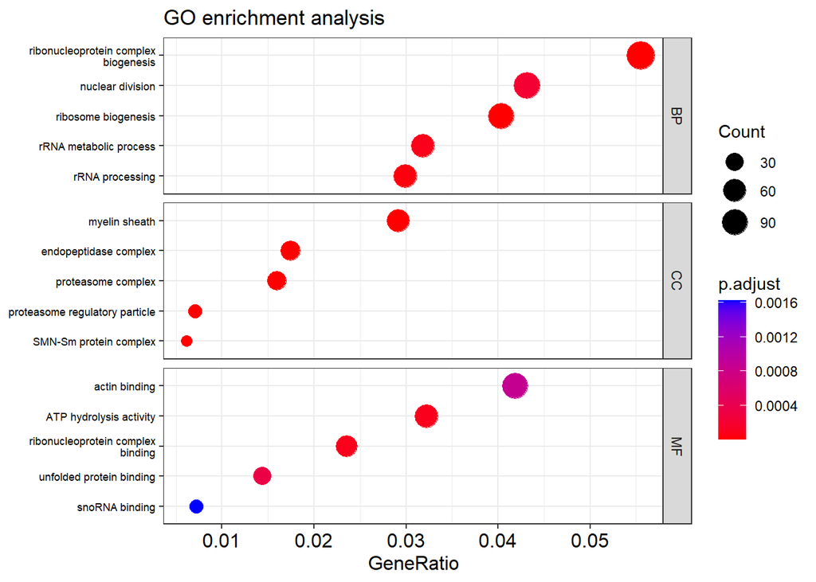

```r
ego <- enrichGO(gene = enriched_pathways,
                universe = all_genes,
                keyType = "ENTREZID",
                OrgDb = org.Mm.eg.db,
                ont = "all",
                pAdjustMethod = "BH",
                qvalueCutoff = 0.05,
                readable = TRUE)
dotplot(ego, split="ONTOLOGY", showCategory = 5) + ggtitle("GO enrichment analysis") +
  theme(axis.text.y = element_text(size = rel(0.75))) +
  facet_grid(ONTOLOGY~., scale="free")
```